# Exercise 4: Cluster Analysis

The number of clusters was fairly consistent across most methods, but there were some differences. The complete linkage (hc1) and Ward’s method (hc4) both suggested at least two main clusters, while the standardized complete linkage (hc3) indicated three clusters. In contrast, the single linkage method (hc2) resulted in only 1 somehat ambiguous cluster (due to chaining).

```r
# Provide your R codes here (if applicable)
```

2. **QUESTION 3.2**: Which cluster analysis gave the clearest result? Justify your answer briefly.

Ward’s method produced the clearest result. The dendrogram shows two clear clusters that remain separate until merging at a very high dissimilarity height (~18), indicating strong separation between groups. This method also avoids the problematic chaining seen in the single linkage dendrogram and produces more compact clusters than the complete linkage methods.

```r
# Provide your R codes here (if applicable)
```

**QUESTION 4.0**: Select one of your hierarchical cluster methods. For the selected method, annotate the tree dendrogram to show the clusters and add this as a new figure. Remember to include a figure caption at the bottom of your figure. (i.e., Figure 5. ?? caption here??…)

**Your Answer:**

Providing the k=2plot from earlier, with extra annotations.

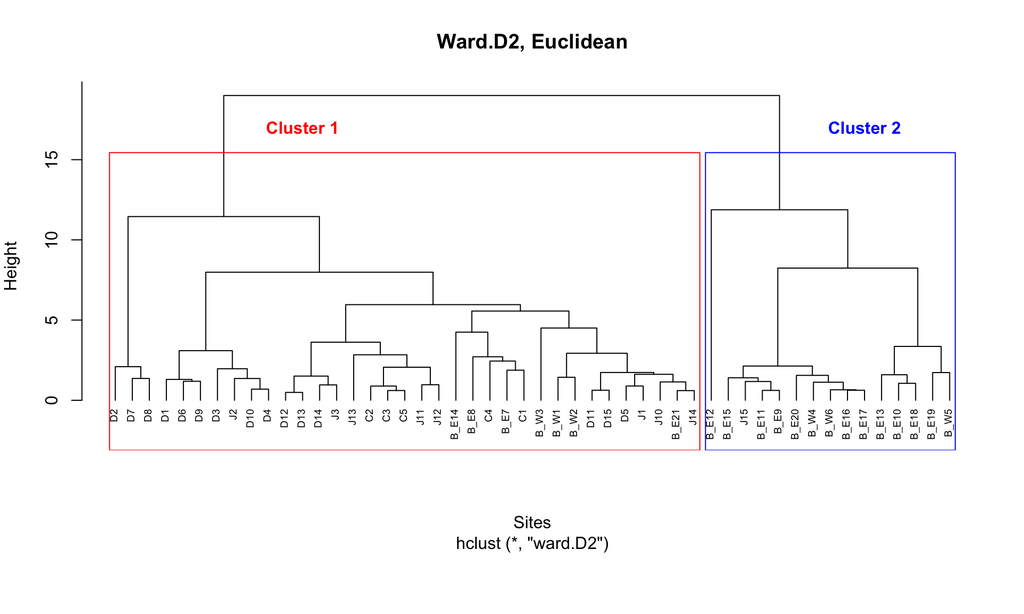

Figure 5. Annotated dendrogram for Ward’s hierarchical clustering using Euclidean distance, showing two clusters.

```r
par(mar = c(8,4,4,2))
plot(hc4, labels = clusdat$point, hang = -1,
     main = "Ward.D2, Euclidean",
     xlab = "Sites", ylab = "Height", cex = 0.6)

rect.hclust(hc4, k = 2, border = c("red","blue"))

# Add cluster labels (adjust x/y slightly if needed)
text(x = 12, y = 17, labels = "Cluster 1", col = "red", font = 2)
text(x = 45, y = 17, labels = "Cluster 2", col = "blue", font = 2)
```

## Part 3: Non-Hierarchical Clustering of sites by bird composition

In Part 3, you will use k-means non-Hierarchical clustering to cluster sites based on bird composition. Remember that the number of clusters is an input variable for k-means. The following code will try inputting 1 to 6 clusters separately, and you will need to interpret the results and choose the likely “natural” number of clusters.

```r
# Again, subset the data to retain just the bird info.
justx<-clusdat[,3:12]
n <- nrow(justx)

## calculate the within sums of squares (wss) for 1 to 6 clusters
wss <- rep(0, 6)
# calculate the wss when only having 1 cluster
wss[1] <- (n - 1) * sum(sapply(justx, var))
# calculate wss when having 2 to 6 clusters for k-means
for (i in 2:6)
   wss[i] <- sum(kmeans(justx, centers = i)$withinss)

# print out the wss for each scenario
wss
```

[output not shown]

In order to choose the likely “natural” number of clusters, plotting the within sums of squares against the number of of clusters could be beneficial.

```r
plot(1:6, wss, type = "b", xlab = "Number of groups",
   ylab = "Within groups sum of squares")
```

[output not shown]

In addition to the wss plot, graphing the clustering results also helps us make a decision. The following code shows an example of where three clusters are formed (but that three-clusters may not be the best choice). You can modify the code and try to graph other scenarios.

```r
## clustering results when forming 3 groups

require(graphics, stats)

# k-means with 3 clusters
(threegroups <- kmeans(justx, centers = 3))  # since this is in brackets, the object - threegroups - is created and then also "printed" out.

# add the cluster no to justx
str(threegroups)
names(justx)
Keep <- data.frame(justx, as.factor(threegroups$cluster))
head(Keep) # cluster number is added to the data.

# shows the summary of clusters
summary(Keep) # most are in Cluster 1 here, with the 3 cluster solution.
```

We could also graph showing the clusters number and two of the bird species. The example below indicates which sites have a similar bird composition in terms of “hola” and “vesp” under the 3-cluster solution.

```r
plot(justx[ ,c("hola","vesp")], xlab = "hola",
     ylab = "Vesper sparrow", pch = 16, col = threegroups$cluster,
     cex = 2.0)
text(clusdat[ ,"hola"], clusdat[ ,"vesp"],
     labels = row.names(justx),cex=0.7,
     pos = 3)
```

[output not shown]

**QUESTION 5.0**: Using the k-means non-hierarchical method, how many natural clusters does there seem to be? For this, show the graph of the within sums of squares versus the number of clusters and add a figure caption. Then use this in justifying your choice of the number of clusters.

**Your Answer:**

```r
# Provide your R codes here (if applicable)
```

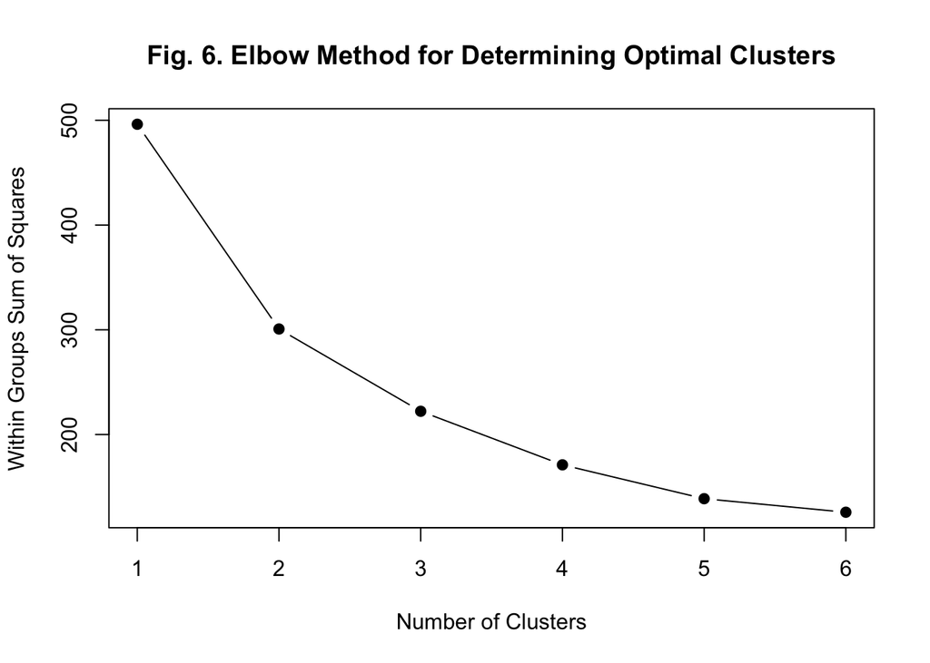

```r
# Provide your R codes here (if applicable)
# Subset bird data
justx <- clusdat[,3:12]

n <- nrow(justx)

# calculate WSS
wss <- rep(0,6)

# 1 cluster
wss[1] <- (n-1) * sum(sapply(justx, var))

# 2–6 clusters
for(i in 2:6){
  wss[i] <- sum(kmeans(justx, centers=i)$withinss)
}

# plot elbow plot
plot(1:6, wss,
     type="b",
     pch=19,
     xlab="Number of Clusters",
     ylab="Within Groups Sum of Squares",
     main="Fig. 6. Elbow Method for Determining Optimal Clusters")
```

Until now, you have explored various hierarchical and non-hierarchical clustering analyses. It’s time for you to make a detailed comparison and choose your best segregation solution.

**QUESTION 6.0**: Compare your selected hierarchical clustering analysis to the non-hierarchical k-means results in terms of: 1) Was there consistency in the number of natural clusters? and 2) Which was easier to interpret/use for this problem?

**Your Answer:** The hierarchical clustering results were generally consistent with the k-means clustering results. The Ward hierarchical method suggested two main clusters, and the k-means elbow method also indicated two natural clusters. This consistency suggests confidence in the clustering result.

In terms of interpretation, hierarchical clustering was easier to interpret because the dendrogram visually shows how sites merge at different dissimilarity levels, making it easier to see the cluster structure and relationships among sites. In contrast, k-means primarily provides cluster assignments and requires additional plots or diagnostics, like the elbow plot, to determine the number of clusters.

```r
# k-means with 2 clusters
set.seed(123)
twogroups <- kmeans(justx, centers = 2)

# Ward clusters cut into 2 groups
ward_clusters <- cutree(hc4, k = 2)

# Compare assignments
comparison <- data.frame(
  Site = row.names(justx),
  Ward_Cluster = ward_clusters,
  Kmeans_Cluster = twogroups$cluster
)

knitr::kable(comparison,
             caption = "Table 2. Comparison of site assignments between Ward hierarchical clustering and k-means clustering using two clusters.")
```

Table 2. Comparison of site assignments between Ward hierarchical clustering and k-means clustering using two clusters.

| Site | Ward_Cluster | Kmeans_Cluster |
| --- | --- | --- |
| 1 | 1 | 2 |
| 2 | 1 | 1 |
| 3 | 1 | 2 |
| 4 | 1 | 2 |
| 5 | 2 | 1 |
| 6 | 1 | 1 |
| 7 | 1 | 1 |
| 8 | 1 | 1 |
| 9 | 1 | 2 |
| 10 | 1 | 2 |
| 11 | 1 | 1 |
| 12 | 2 | 1 |
| 13 | 2 | 1 |
| 14 | 2 | 1 |
| 15 | 1 | 1 |
| 16 | 2 | 1 |
| 17 | 2 | 1 |
| 18 | 2 | 1 |
| 19 | 1 | 1 |
| 20 | 1 | 2 |
| 21 | 1 | 1 |
| 22 | 2 | 1 |
| 23 | 2 | 1 |
| 24 | 2 | 1 |
| 25 | 2 | 1 |
| 26 | 2 | 1 |
| 27 | 2 | 1 |
| 28 | 2 | 1 |
| 29 | 2 | 1 |
| 30 | 2 | 1 |
| 31 | 2 | 1 |
| 32 | 2 | 1 |
| 33 | 2 | 1 |
| 34 | 2 | 1 |
| 35 | 2 | 1 |
| 36 | 2 | 1 |
| 37 | 2 | 1 |
| 38 | 2 | 1 |
| 39 | 2 | 1 |
| 40 | 2 | 1 |
| 41 | 2 | 1 |
| 42 | 2 | 1 |
| 43 | 2 | 1 |
| 44 | 2 | 1 |
| 45 | 2 | 1 |
| 46 | 2 | 1 |
| 47 | 2 | 1 |
| 48 | 1 | 1 |
| 49 | 2 | 1 |
| 50 | 2 | 1 |

**QUESTION 7.0**: Overall, based on your analyses and interpretation, which clustering method would you recommend of the five methods used? Briefly explain your choice.

The dendrogram produced by Ward’s method also showed a clear separation between **t**wo main groups of sites, suggesting that the dataset naturally divides into two clusters based on bird species composition. This interpretation was further supported by the k means analysis, where the elbow plot indicated that two clusters best represented the natural structure of the data.

Overall, because Ward’s method produced the most compact clusters, the clearest separation between groups, and results consistent with the k means analysis, it appears to be the most appropriate clustering approach for this dataset.

```r
# Provide your R codes here (if applicable)
```

## Extra R code, Part 4: Non-Hierarchical Clustering of birds by locations

Below is extra code where the data are transposed and the objective is to cluster the birds based on locations that they exist (i.e., Which birds appear to be together?) This is just for fun, and shows how the clustering can be altered to group variables instead of observations to match the question posed.

### Data Preparation

First, let’s just take 25 rows this time and transpose the data.

```r
justxT<-t(justx[1:25,])
head(justxT)
```

### K-means clustering

Using k-means, cluster the birds into into 1 to 6 clusters based on sites where they occur. Then, choose the likely “natural” number of clusters.

```r
n <- nrow(justxT)

wss <- rep(0, 6)
wss[1] <- (n - 1) * sum(sapply(justxT, var)) # 1 cluster wss
for (i in 2:6)
   wss[i] <- sum(kmeans(justxT,
   centers = i)$withinss)
wss  # within sums of squares for 1 to 6 clusters

plot(1:6, wss, type = "b", xlab = "Number of groups",
   ylab = "Within groups sum of squares")
```

[output not shown]

Graph the three-group solution in below… but that may not be the best one?

```r
## clustering results when forming 3 groups

require(graphics, stats)

(threegroups <- kmeans(justxT, centers = 3))

str(threegroups) # includes the cluster no, etc.
Keep3<-data.frame(justxT,as.factor(threegroups$cluster) )
head(Keep3) # cluster number is added to the data.
summary(Keep3) # most are in Cluster 1 here.
```

Let’s check the four-group solution as well.

```r
## clustering results when forming 4 groups

(fourgroups <- kmeans(justxT, centers = 4))

str(fourgroups) # includes the cluster no, etc.
Keep4<-data.frame(justxT,as.factor(fourgroups$cluster) )
head(Keep4) # cluster number is added to the data.

summary(Keep4) # most are in Cluster 3 here, with the 4 cluster solution.
```

Here is another graphic, showing the scatterplot matrix, but with points labelled. The upper panel is the 4-group solution and the lower panel is the 3-group solution. color schemes for K-means… adapted from Zellerman code example.

```r
colorlow <- rainbow(3)[threegroups$cluster]
colorup <- rainbow(4)[fourgroups$cluster]
panel.up <- function(x, y, ...)
{ # function to produce scatterplot in pairs()
  usr <- par("usr") # save par() values
  on.exit(par(usr)) # set par() at end
  par(usr = c(max(y), min(y), max(x), min(x))) # set bounds
  points(y, x, col = colorup, pch = 16) # plot data points
}
pairs(justxT, pch = 16, gap = 0, xaxt = "n", yaxt = "n",
col = colorlow, upper.panel = panel.up)
```

[output not shown]

[output not shown]

[output cut: 245 more lines]

[output not shown]

You can use the following code to generate statistics by cluster.

```r
dim(Keep4)
summary(Keep4)

cluster1<-Keep4[(Keep4$as.factor.fourgroups.cluster==1),]
cluster2<-Keep4[(Keep4$as.factor.fourgroups.cluster==2),]
cluster3<-Keep4[(Keep4$as.factor.fourgroups.cluster==3),]
cluster4<-Keep4[(Keep4$as.factor.fourgroups.cluster==4),]

dim(cluster1)
dim(cluster2)
dim(cluster3)
dim(cluster4)

rownames(cluster1) # what birds in cluster 1?
rownames(cluster2)
rownames(cluster3)
rownames(cluster4)
```